# HTML形式のR Markdownサンプル

Pandoc2.7.2推奨

niszet

niszet@niszet.com

niszet2

nisnis@zetzet.com

2019/4/13

Abstract

TokyoR 77 で使用するR MarkdownのHTML出力形式のサンプルコードとファイル

# 1 HTML Sample of R Markdown

`output:html_document`を指定したときの出力結果を確認する。

## 1.1 まずは作ってみよう

### 1.1.1 新規ファイルの作成

R Studioのメニュー、`[File]` - `[New File]` - `[R Markdown]` を選択してDocumentのHTMLを選択。 titleに「はじめてのR Markdown」、Authorに名前を入れてみる。

### 1.1.2 Knit

Source Pane上部にあるKnitのボタンを押す

## 1.2 R Markdownファイルの構成

- 拡張子をRmdとして保存。
- YAMLというデータの書き方を使ってパラメータやR Markdownの挙動を制御する
- 本文はMarkdownの文法を使って書く
- Rのコードはチャンクと呼ばれる

## 1.3 YAML

このHTMLファイルのYAMLは以下のとおり。

```yaml
title: HTML形式のR Markdownサンプル
subtitle: Pandoc2.7.2推奨
author:
  - name: "niszet"
    email: "niszet@niszet.com"
  - name: "niszet2"
    email: "nisnis@zetzet.com"
date: "2019/4/13"
kable-scroll: True
abstract: TokyoR 77 で使用するR MarkdownのHTML出力形式のサンプルコードとファイル
output:
  html_document:
    toc: TRUE
    toc_depth: 2
    toc_float:
      collapsed: true
      smooth_scroll: true
    number_sections: true
    section_divs: True
    fig_caption: True
    df_print: paged
    code_folding: hide
    code_download: True
    theme: united
    highlight: tango
    md_extensions: +abbreviations+task_lists
    pandoc_args: [
      "--title-prefix", "Chapter",
      "--id-prefix", "Bar",
      "--metadata", "pagetitle=hoge" ]
```

## 1.4 いくつかのMarkdown記述例

### 1.4.1 基本

*斜体* **強調** **強調斜体**

行末での改行は 通常は無視される。行末に半角スペース2つ  
あるいはバックスラッシュ`\`を入れると  
その場所で改行される。

### 1.4.3 リスト

- リスト1
- リスト2
  - リスト2-1
  - リスト2-2
1. リスト10
2. リスト11
   1. リスト11-1
   2. リスト11-2

### 1.4.4 ブロック引用

> ブロック引用。

> > 複数の引用の`>`の間にスペースがあればネストした引用の表示になる

### 1.4.5 Task List

`md_extensions:` に `+task_lists`を追加すると、チェックリストが作れる。

- チェックが入っていない場合
- チェックが入っている場合

## 1.5 数式

$\LaTeX$ の数式の書き方が使える。

$$I_{ds} = \frac{1}{2}\mu C_{ox} \frac{W}{L} \left( V_{gs} - V_{th} \right)^2$$

## 1.6 表

### 1.6.1 pagedを指定した表の表示例

YAML中で`df_print:paged`を指定しているので、列が多いdata.frameは複数ページに表示されるようになる。

```r
mtcars
```

|  | mpg | cyl | disp | hp | drat | wt | qsec | vs | am | gear | carb |
| --- | --- | --- | --- | --- | --- | --- | --- | --- | --- | --- | --- |
| Mazda RX4 | 21.0 | 6 | 160.0 | 110 | 3.90 | 2.620 | 16.46 | 0 | 1 | 4 | 4 |
| Mazda RX4 Wag | 21.0 | 6 | 160.0 | 110 | 3.90 | 2.875 | 17.02 | 0 | 1 | 4 | 4 |
| Datsun 710 | 22.8 | 4 | 108.0 | 93 | 3.85 | 2.320 | 18.61 | 1 | 1 | 4 | 1 |
| Hornet 4 Drive | 21.4 | 6 | 258.0 | 110 | 3.08 | 3.215 | 19.44 | 1 | 0 | 3 | 1 |
| Hornet Sportabout | 18.7 | 8 | 360.0 | 175 | 3.15 | 3.440 | 17.02 | 0 | 0 | 3 | 2 |
| Valiant | 18.1 | 6 | 225.0 | 105 | 2.76 | 3.460 | 20.22 | 1 | 0 | 3 | 1 |
| Duster 360 | 14.3 | 8 | 360.0 | 245 | 3.21 | 3.570 | 15.84 | 0 | 0 | 3 | 4 |
| Merc 240D | 24.4 | 4 | 146.7 | 62 | 3.69 | 3.190 | 20.00 | 1 | 0 | 4 | 2 |
| Merc 230 | 22.8 | 4 | 140.8 | 95 | 3.92 | 3.150 | 22.90 | 1 | 0 | 4 | 2 |
| Merc 280 | 19.2 | 6 | 167.6 | 123 | 3.92 | 3.440 | 18.30 | 1 | 0 | 4 | 4 |

[output cut: 22 more lines]

### 1.6.2 `knitr::kable()`を使った例

`knitr::kable()`を使って表示するとこのようになる。

```r
knitr::kable(head(iris))
```

| Sepal.Length | Sepal.Width | Petal.Length | Petal.Width | Species |
| --- | --- | --- | --- | --- |
| 5.1 | 3.5 | 1.4 | 0.2 | setosa |
| 4.9 | 3.0 | 1.4 | 0.2 | setosa |
| 4.7 | 3.2 | 1.3 | 0.2 | setosa |
| 4.6 | 3.1 | 1.5 | 0.2 | setosa |
| 5.0 | 3.6 | 1.4 | 0.2 | setosa |
| 5.4 | 3.9 | 1.7 | 0.4 | setosa |

kableExtra パッケージなどもおススメ https://cran.r-project.org/web/packages/kableExtra/vignettes/awesome_table_in_html.html

## 1.7 tabset を使う例

HTML形式の出力の場合、`tabset`関連の設定でこのように表示できる

### 1.7.1 Sepal.Length

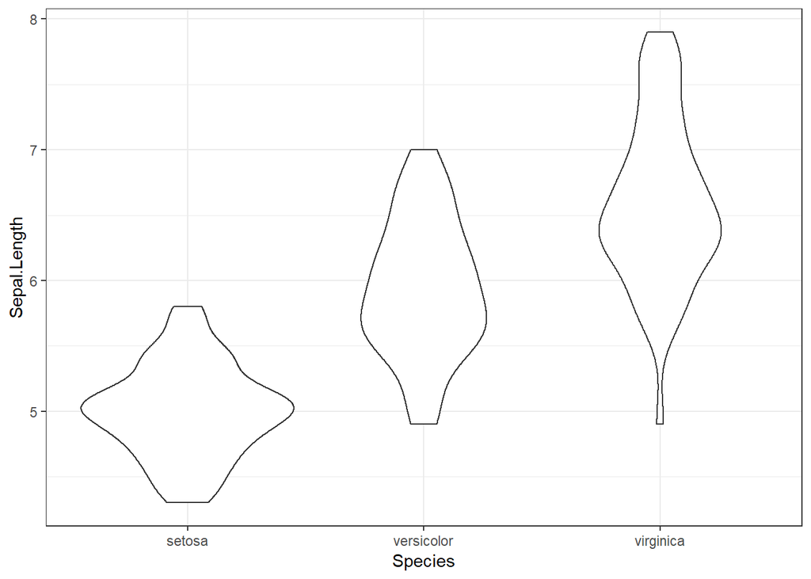

```r
iris %>% ggplot()+geom_violin(aes(x=Species, y=Sepal.Length))+theme_bw()
```

### 1.7.2 Sepal.Width

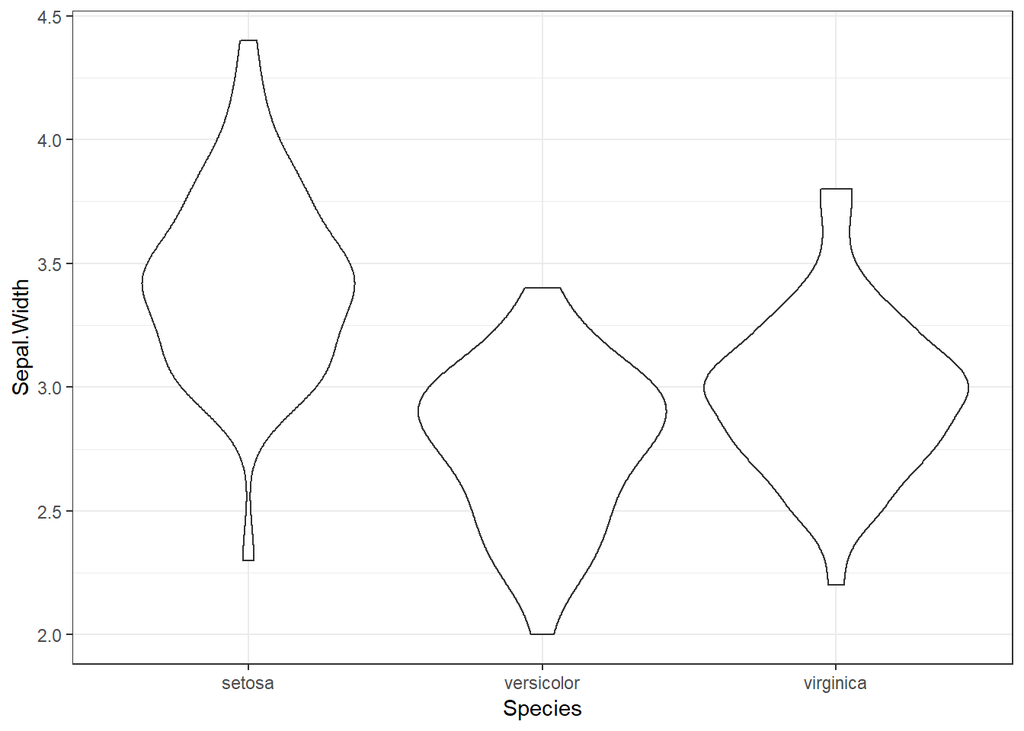

```r
iris %>% ggplot()+geom_violin(aes(x=Species, y=Sepal.Width))+theme_bw()
```

### 1.7.3 Petal.Length

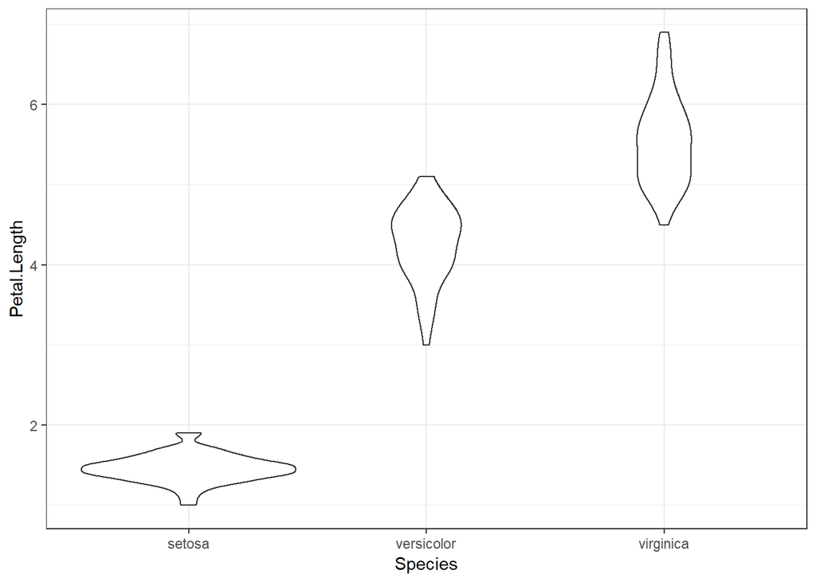

```r
iris %>% ggplot()+geom_violin(aes(x=Species, y=Petal.Length))+theme_bw()
```

### 1.7.4 Petal.Width

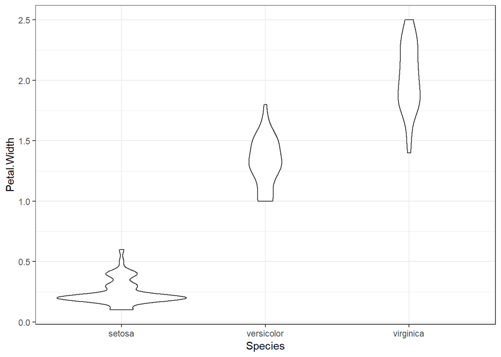

```r
iris %>% ggplot()+geom_violin(aes(x=Species, y=Petal.Width))+theme_bw()
```

## 1.8 plotlyパッケージを使用する

```r
g <- iris %>% ggplot()+geom_point(aes(x=Sepal.Width, y=Petal.Width, color=Species))+theme_bw()
g %>% plotly::ggplotly()
```

[interactive chart not shown]

1. このように表示される。
2. しかし、地の文と区別がつきにくいので多用は厳禁